# Pre-Registration

Kathrin Reichmann

September 2021

## Category Size and Generalization in EC

Contains models of three previous tasks: (1) Direct evaluative ratings (2) AMP (3) DRM

### Direct Evaluative ratings

**(1) Analysis of Difference scores:**

**H1** Wider generalization when the category size is large, in comparison to the small category size. This translates into a significant category size x stimulus type interaction. We expect this for both evaluative ratings and the AMP.

**ANOVA**

```
## Contrasts set to contr.sum for the following variables: condition
```

```
## Anova Table (Type 3 tests)
##
## Response: diff
##                    Effect     df     MSE         F  ges p.value
## 1               condition 1, 198 4596.14      2.49 .010    .116
## 2           type_specific 1, 198 1041.33 79.89 *** .069   <.001
## 3 condition:type_specific 1, 198 1041.33 12.60 *** .012   <.001
## ---
## Signif. codes:  0 '***' 0.001 '**' 0.01 '*' 0.05 '+' 0.1 ' ' 1
```

```
## # Effect Size for ANOVA (Type III)
##
## Parameter               | Eta2 (partial) |       90% CI
## -------------------------------------------------------
## condition               |           0.01 | [0.00, 0.05]
## type_specific           |           0.29 | [0.20, 0.37]
## condition:type_specific |           0.06 | [0.02, 0.12]
```

**mixed effect models**

Diff score per individual, type and category e.g. [VP1 CS cat1 pos] - [VP1 CS cat2 neg] condition (-0.5 = one, 0.5 = many), type (-0.5 = CS, 0.5 = GS)

Model with random intercepts for participants: lmer(diff ~ condition* type + (1|subject))

*significant interaction: H1*

```r
## specify models
lmer1Diff <- lmer(diff ~ condition_effect*type_effect
                  + (1|subject),
                  directDiff, REML = FALSE)

lmer2Diff <- lmer(diff ~ condition_effect*type_effect
                  + (type_effect|subject),
                  directDiff, REML = FALSE)
```

```
## boundary (singular) fit: see ?isSingular
```

```r
anova(lmer1Diff, lmer2Diff)
```

```
## Data: directDiff
## Models:
## lmer1Diff: diff ~ condition_effect * type_effect + (1 | subject)
## lmer2Diff: diff ~ condition_effect * type_effect + (type_effect | subject)
##           npar   AIC   BIC  logLik deviance  Chisq Df Pr(>Chisq)
## lmer1Diff    6 17752 17785 -8870.2    17740
## lmer2Diff    8 17751 17794 -8867.5    17735 5.3744  2    0.06807 .
## ---
## Signif. codes:  0 '***' 0.001 '**' 0.01 '*' 0.05 '.' 0.1 ' ' 1
```

```r
summary(lmer1Diff, corr = FALSE)
```

```
## Linear mixed model fit by maximum likelihood . t-tests use Satterthwaite's
##   method [lmerModLmerTest]
## Formula: diff ~ condition_effect * type_effect + (1 | subject)
##    Data: directDiff
##
##      AIC      BIC   logLik deviance df.resid
##  17752.4  17784.7  -8870.2  17740.4     1594
##
## Scaled residuals:
##     Min      1Q  Median      3Q     Max
## -3.6617 -0.5769  0.0077  0.6506  2.9141
##
## Random effects:
##  Groups   Name        Variance Std.Dev.
##  subject  (Intercept) 1589     39.86
##  Residual             3124     55.90
## Number of obs: 1600, groups:  subject, 200
##
## Fixed effects:
##                              Estimate Std. Error       df t value Pr(>|t|)
## (Intercept)                    50.114      3.248  227.036  15.430  < 2e-16 ***
## condition_effect               10.706      6.496  227.036   1.648 0.100681
## type_effect                   -28.845      3.227 1400.000  -8.937  < 2e-16 ***
## condition_effect:type_effect   22.911      6.455 1400.000   3.550 0.000399 ***
## ---
## Signif. codes:  0 '***' 0.001 '**' 0.01 '*' 0.05 '.' 0.1 ' ' 1
```

```r
#choose model1
```

Parameter Interpretation: lmer1Diff

**Random Intercept subjects = 39.86** -> variation of intercepts across subjects (goes beyond the fixed effect of stimulus type -> there are substantial interindividual differences in the average evaluative ratings of participants)

**Intercept = 50.114** -> Grand mean (on average, difference scores were 50.114 points)

**Fixed Effect Condition = 10.706** -> main effect condition: The mean difference between conditions in difference scores was 10.706: 10.706 points higher in the “many” condition than in the “one” condition.

**Fixed Effect Type = -28.845** -> main effect type: the mean difference between stimulus types in difference scores was -28.845: 28.845 points lower in for “GSs” than for “CSs”.

**Interaction TypexCondition = 22.91** -> interaction effect condition*type: the difference between “one” and “many” for CSs and “one” and “many” for GSs was 22.91 in total, indicating that the effect of condition was qualified by the type of stimulus.

Simple slopes: lmer (diff ~ type (effect coded) + condition (effect coded): type (dummy coded) + (1|subject))

```r
#model1: analyze simple slopes
lmer1_1Diff <- lmer(diff ~ type_effect + condition_effect:type_specific
                    + (1|subject),
                    directDiff, REML = FALSE)
summary(lmer1_1Diff, corr = FALSE)
```

```
## Linear mixed model fit by maximum likelihood . t-tests use Satterthwaite's
##   method [lmerModLmerTest]
## Formula: diff ~ type_effect + condition_effect:type_specific + (1 | subject)
##    Data: directDiff
##
##      AIC      BIC   logLik deviance df.resid
##  17752.4  17784.7  -8870.2  17740.4     1594
##
## Scaled residuals:
##     Min      1Q  Median      3Q     Max
## -3.6617 -0.5769  0.0077  0.6506  2.9141
##
## Random effects:
##  Groups   Name        Variance Std.Dev.
##  subject  (Intercept) 1589     39.86
##  Residual             3124     55.90
## Number of obs: 1600, groups:  subject, 200
##
## Fixed effects:
##                                   Estimate Std. Error        df t value
## (Intercept)                        50.1139     3.2478  227.0356  15.430
## type_effect                       -28.8446     3.2274 1400.0000  -8.937
## condition_effect:type_specificCS   -0.7493     7.9388  482.7188  -0.094
## condition_effect:type_specificGS   22.1622     6.4956  227.0356   3.412
##                                  Pr(>|t|)
## (Intercept)                       < 2e-16 ***
## type_effect                       < 2e-16 ***
## condition_effect:type_specificCS 0.924845
## condition_effect:type_specificGS 0.000764 ***
## ---
## Signif. codes:  0 '***' 0.001 '**' 0.01 '*' 0.05 '.' 0.1 ' ' 1
```

Parameter Interpretation: lmer1_1Diff

**Interaction TypeCS x Condition = -0.75** -> Effect of condition for CSs is -0.75 (on average, the difference scores are 0.75 points lower in the “many” condition than in the “one” condition, when looking at CSs)

**Interaction TypeGS x Condition = 22.16** -> Effect of condition for GSs is 22.16 (on average, the difference scores are 22.16 points higher in the “many” condition than in the “one” condition, when looking at GSs) -> this is the finding that we are looking for

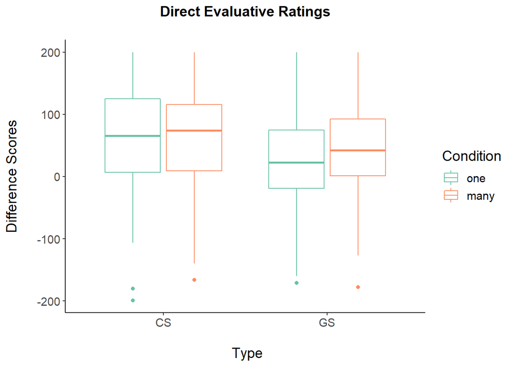

**(2) Include Valence as a factor, use raw evaluative rating scores as DV**

**ANOVA**

```
## Contrasts set to contr.sum for the following variables: condition
```

```
## Anova Table (Type 3 tests)
##
## Response: response
##                        Effect     df     MSE          F   ges p.value
## 1                   condition 1, 198  980.18   10.90 **  .013    .001
## 2               type_specific 1, 198  387.95     4.99 *  .002    .027
## 3     condition:type_specific 1, 198  387.95       0.52 <.001    .471
## 4                         val 1, 198 2298.07 218.54 ***  .377   <.001
## 5               condition:val 1, 198 2298.07       2.49  .007    .116
## 6           type_specific:val 1, 198  520.66  79.89 ***  .048   <.001
## 7 condition:type_specific:val 1, 198  520.66  12.60 ***  .008   <.001
## ---
## Signif. codes:  0 '***' 0.001 '**' 0.01 '*' 0.05 '+' 0.1 ' ' 1
```

```
## # Effect Size for ANOVA (Type III)
##
## Parameter                   | Eta2 (partial) |       90% CI
## -----------------------------------------------------------
## condition                   |           0.05 | [0.01, 0.11]
## type_specific               |           0.02 | [0.00, 0.07]
## condition:type_specific     |       2.63e-03 | [0.00, 0.03]
## val                         |           0.52 | [0.45, 0.59]
## condition:val               |           0.01 | [0.00, 0.05]
## type_specific:val           |           0.29 | [0.20, 0.37]
## condition:type_specific:val |           0.06 | [0.02, 0.12]
```

**mixed models**

condition (-0.5 = one, 0.5 = many), type (-0.5 = CS, 0.5 = GS), val (-0.5 = neg, 0.5 = pos)

Model with random intercepts for participants: lmer(ratings ~ condition* type* val + (1|subject))

```r
#analysis 2: with valence as a factor

#random intercepts
lmer1 <- lmer(response ~ val_effect*condition_effect*type_effect
              + (1|subject),
              direct, REML = FALSE)

#random slopes
lmer2 <- lmer(response ~ val_effect*condition_effect*type_effect
              + (val_effect*type_effect|subject),
              direct, REML = FALSE)
```

```
## boundary (singular) fit: see ?isSingular
```

```r
anova(lmer1, lmer2)
```

```
## Data: direct
## Models:
## lmer1: response ~ val_effect * condition_effect * type_effect + (1 | subject)
## lmer2: response ~ val_effect * condition_effect * type_effect + (val_effect * type_effect | subject)
##       npar   AIC   BIC logLik deviance  Chisq Df Pr(>Chisq)
## lmer1   10 33651 33711 -16815    33631
## lmer2   19 33298 33413 -16630    33260 370.81  9  < 2.2e-16 ***
## ---
## Signif. codes:  0 '***' 0.001 '**' 0.01 '*' 0.05 '.' 0.1 ' ' 1
```

```r
summary(lmer2, corr = FALSE)
```

```
## Linear mixed model fit by maximum likelihood . t-tests use Satterthwaite's
##   method [lmerModLmerTest]
## Formula:
## response ~ val_effect * condition_effect * type_effect + (val_effect *
##     type_effect | subject)
##    Data: direct
##
##      AIC      BIC   logLik deviance df.resid
##  33297.8  33413.2 -16629.9  33259.8     3181
##
## Scaled residuals:
##     Min      1Q  Median      3Q     Max
## -3.5698 -0.6734  0.0281  0.6589  2.8723
##
## Random effects:
##  Groups   Name                   Variance Std.Dev. Corr
##  subject  (Intercept)             116.79  10.807
##           val_effect             1734.13  41.643   -0.24
##           type_effect               1.78   1.334    0.69  0.54
##           val_effect:type_effect   77.50   8.803    0.56 -0.94 -0.22
##  Residual                        1651.90  40.644
## Number of obs: 3200, groups:  subject, 200
##
## Fixed effects:
##                                         Estimate Std. Error       df t value
## (Intercept)                                3.637      1.128  216.442   3.224
## val_effect                                50.114      3.380  200.772  14.826
## condition_effect                          -7.310      2.256  216.442  -3.240
## type_effect                               -3.113      1.662 2508.725  -1.873
## val_effect:condition_effect               10.706      6.760  200.772   1.584
## val_effect:type_effect                   -28.845      3.377 1339.321  -8.543
## condition_effect:type_effect               2.012      3.324 2508.725   0.605
## val_effect:condition_effect:type_effect   22.911      6.753 1339.321   3.393
##                                         Pr(>|t|)
## (Intercept)                             0.001458 **
## val_effect                               < 2e-16 ***
## condition_effect                        0.001382 **
## type_effect                             0.061195 .
## val_effect:condition_effect             0.114823
## val_effect:type_effect                   < 2e-16 ***
## condition_effect:type_effect            0.545063
## val_effect:condition_effect:type_effect 0.000712 ***
## ---
## Signif. codes:  0 '***' 0.001 '**' 0.01 '*' 0.05 '.' 0.1 ' ' 1
## optimizer (nloptwrap) convergence code: 0 (OK)
## boundary (singular) fit: see ?isSingular
```

```r
#choose model2
```

simple slopes:

Model with random intercepts and slopes for participants: lmer(diff ~ type (effect coded) * val (effect coded) + condition (effect coded)* type (dummy coded) * val(dummy coded) + (type(effect coded) * (effect coded)|subject))

```r
#model2
lmer1_2 <- lmer(response ~ val_effect*type_effect + condition_effect:val:type_specific
                + (val_effect*type_effect|subject),
                direct, REML = FALSE)
```

```
## boundary (singular) fit: see ?isSingular
```

```r
summary(lmer1_2, corr = FALSE)
```

```
## Linear mixed model fit by maximum likelihood . t-tests use Satterthwaite's
##   method [lmerModLmerTest]
## Formula:
## response ~ val_effect * type_effect + condition_effect:val:type_specific +
##     (val_effect * type_effect | subject)
##    Data: direct
##
##      AIC      BIC   logLik deviance df.resid
##  33297.8  33413.2 -16629.9  33259.8     3181
##
## Scaled residuals:
##     Min      1Q  Median      3Q     Max
## -3.5699 -0.6734  0.0281  0.6590  2.8723
##
## Random effects:
##  Groups   Name                   Variance Std.Dev. Corr
##  subject  (Intercept)             116.808 10.808
##           val_effect             1734.097 41.642   -0.24
##           type_effect               1.776  1.333    0.69  0.54
##           val_effect:type_effect   77.468  8.802    0.56 -0.94 -0.22
##  Residual                        1651.898 40.644
## Number of obs: 3200, groups:  subject, 200
##
## Fixed effects:
##                                         Estimate Std. Error       df t value
## (Intercept)                                3.637      1.128  216.432   3.224
## val_effect                                50.114      3.380  200.774  14.826
## type_effect                               -3.113      1.662 2509.332  -1.873
## val_effect:type_effect                   -28.845      3.377 1339.594  -8.543
## condition_effect:valneg:type_specificCS   -7.941      5.673  236.683  -1.400
## condition_effect:valpos:type_specificCS   -8.691      5.112  266.526  -1.700
## condition_effect:valneg:type_specificGS  -17.385      4.057  204.854  -4.285
## condition_effect:valpos:type_specificGS    4.777      3.705  204.092   1.289
##                                         Pr(>|t|)
## (Intercept)                              0.00146 **
## val_effect                               < 2e-16 ***
## type_effect                              0.06119 .
## val_effect:type_effect                   < 2e-16 ***
## condition_effect:valneg:type_specificCS  0.16287
## condition_effect:valpos:type_specificCS  0.09030 .
## condition_effect:valneg:type_specificGS 2.81e-05 ***
## condition_effect:valpos:type_specificGS  0.19881
## ---
## Signif. codes:  0 '***' 0.001 '**' 0.01 '*' 0.05 '.' 0.1 ' ' 1
## optimizer (nloptwrap) convergence code: 0 (OK)
## boundary (singular) fit: see ?isSingular
```

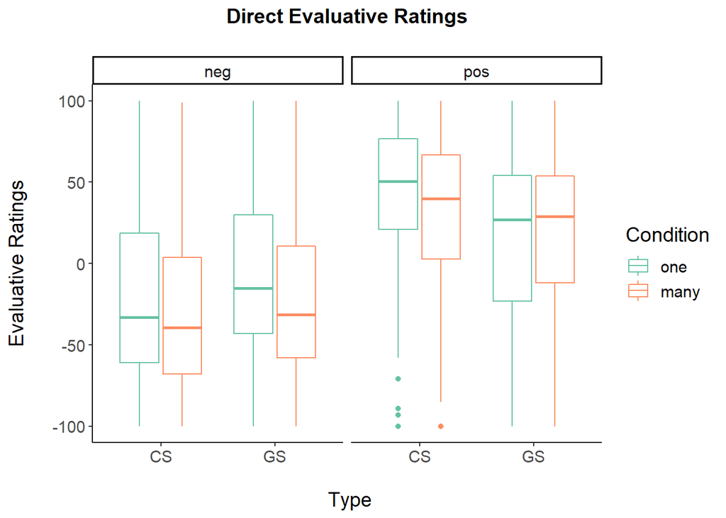

### AMP

**(1) Analysis of Difference scores:**

**H1** Wider generalization when the category size is large, in comparison to the small category size. This translates into a significant category size x stimulus type interaction with a positive parameter estimate. We expect this for both evaluative ratings and the AMP.

Difference scores: per participant and stimulus type: [proportion of “angenehm” responses for +] - [proportion of “angenehm” responeses for -]

condition (-0.5 = one, 0.5 = many), type (-0.5 = CS, 0.5 = GS)

Model with random intercepts for participants: lmer(diff ~ condition* type + (1|subject))

*signifikant interaction: H1*

```r
#model specification
lmer1Diff <- lmer(diff ~ condition_effect*type_effect + (1|subject), indirectDiff, REML = FALSE)

#lmer2Diff <- lmer(diff ~ condition_effect*type_effect + (type_effect|subject), indirectDiff, REML=FALSE)
#model 2 not specifiable due to missing observations

#anova(lmer1Diff, lmer2Diff)

summary(lmer1Diff, corr = FALSE)
```

```
## Linear mixed model fit by maximum likelihood . t-tests use Satterthwaite's
##   method [lmerModLmerTest]
## Formula: diff ~ condition_effect * type_effect + (1 | subject)
##    Data: indirectDiff
##
##      AIC      BIC   logLik deviance df.resid
##    474.8    498.7   -231.4    462.8      394
##
## Scaled residuals:
##      Min       1Q   Median       3Q      Max
## -2.75082 -0.52988  0.07464  0.67512  1.90942
##
## Random effects:
##  Groups   Name        Variance Std.Dev.
##  subject  (Intercept) 0.02478  0.1574
##  Residual             0.16307  0.4038
## Number of obs: 400, groups:  subject, 200
##
## Fixed effects:
##                               Estimate Std. Error        df t value Pr(>|t|)
## (Intercept)                    0.17160    0.02306 200.00000   7.442 2.87e-12
## condition_effect               0.06927    0.04611 200.00000   1.502    0.135
## type_effect                   -0.05715    0.04038 200.00000  -1.415    0.159
## condition_effect:type_effect   0.07052    0.08077 200.00000   0.873    0.384
##
## (Intercept)                  ***
## condition_effect
## type_effect
## condition_effect:type_effect
## ---
## Signif. codes:  0 '***' 0.001 '**' 0.01 '*' 0.05 '.' 0.1 ' ' 1
```

Simple slopes: lmer (diff ~ type (effect coded) + condition (effect coded): type (dummy coded) + (1|subject))

```r
#simple slopes
lmer1Diff_1 <- lmer(diff ~ type_effect + type_specific:condition_effect + (1|subject), indirectDiff, REML = FALSE)
summary(lmer1Diff_1, corr = FALSE)
```

```
## Linear mixed model fit by maximum likelihood . t-tests use Satterthwaite's
##   method [lmerModLmerTest]
## Formula: diff ~ type_effect + type_specific:condition_effect + (1 | subject)
##    Data: indirectDiff
##
##      AIC      BIC   logLik deviance df.resid
##    474.8    498.7   -231.4    462.8      394
##
## Scaled residuals:
##      Min       1Q   Median       3Q      Max
## -2.75082 -0.52988  0.07464  0.67512  1.90942
##
## Random effects:
##  Groups   Name        Variance Std.Dev.
##  subject  (Intercept) 0.02478  0.1574
##  Residual             0.16307  0.4038
## Number of obs: 400, groups:  subject, 200
##
## Fixed effects:
##                                   Estimate Std. Error        df t value
## (Intercept)                        0.17160    0.02306 200.00000   7.442
## type_effect                       -0.05715    0.04038 200.00000  -1.415
## type_specificCS:condition_effect   0.03400    0.06130 393.15958   0.555
## type_specificGS:condition_effect   0.10453    0.06130 393.15958   1.705
##                                  Pr(>|t|)
## (Intercept)                      2.87e-12 ***
## type_effect                        0.1586
## type_specificCS:condition_effect   0.5794
## type_specificGS:condition_effect   0.0889 .
## ---
## Signif. codes:  0 '***' 0.001 '**' 0.01 '*' 0.05 '.' 0.1 ' ' 1
```

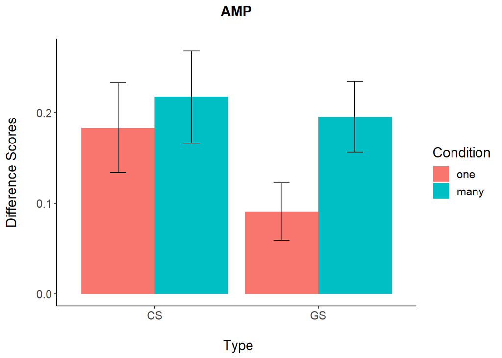

**(2) Include Valence as a factor, use prop “angenehm” as DV**

response: 1 = “angenehm”, 0 = “unangenehm” condition (-0.5 = one, 0.5 = many), type (-0.5 = CS, 0.5 = GS), val (-0.5 = neg, 0.5 = pos)